# Consumer research

Block 6 · exercises 10 – 12

Sensometrics in R · SaIT

## Shelf life through the consumer’s eyes

- Microbiological shelf life: when the product is **unsafe**
- Sensory shelf life: when the consumer **rejects** it

Event = **rejection**. If an assessor did not reject the product by the end of the test, the observation is **censored** – we only know it lasted at least that long. This is exactly what survival analysis handles.

## Kaplan-Meier curve

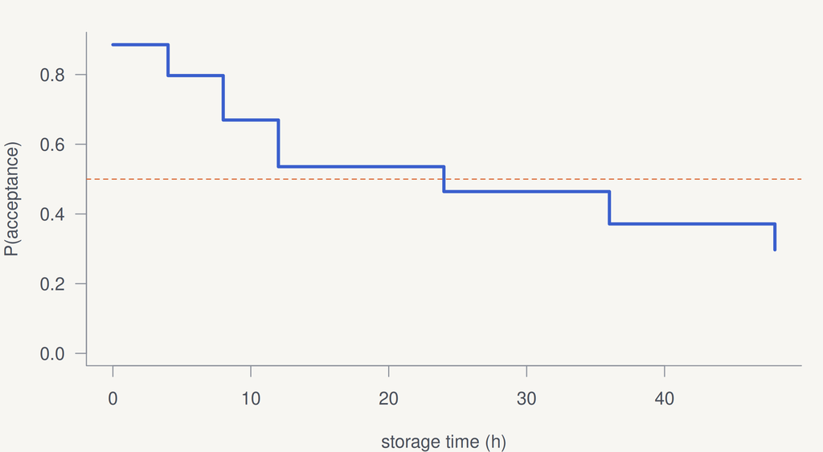

```r
time <- rep(c(0, 4, 8, 12, 24, 36, 48), 5)
rejected <- c(1,1,1,1,0,0,0, 1,1,1,1,1,1,1,
              1,1,0,1,0,0,0, 1,0,1,0,0,0,0,
              0,0,1,1,1,1,0) == 1
fit <- survfit(Surv(time, rejected) ~ 1)
plot(fit, conf.int = FALSE, lwd = 3,
     col = pal[3], xlab = "storage time (h)",
     ylab = "P(acceptance)")
abline(h = 0.5, col = pal[2], lty = 2)
```

```r
fit
```

```
Call: survfit(formula = Surv(time, rejected) ~ 1)

      n events median 0.95LCL 0.95UCL
[1,] 35     20     24      12      NA
```

Median sensory shelf life = the time at which the curve drops below 0.5.

## TURF – reach and frequency

A pizzeria can offer only 3 – 4 ingredients. We do not want the **most popular** ones, but those that **together reach the most different** customers.

| indicator | question |
| --- | --- |
| **Reach** | what % of customers like at least one item? |
| **Frequency** | how many liked items does a customer have on average? |

## TURF in practice

```r
set.seed(11)
n <- 150
p <- c(cheese = 0.7, ham = 0.6, salami = 0.55, olives = 0.3, corn = 0.35, bacon = 0.4)
likes <- sapply(p, function(pi) rbinom(n, 1, pi))
combos <- combn(names(p), 3)
reach <- apply(combos, 2, function(k) mean(rowSums(likes[, k]) > 0))
best <- order(reach, decreasing = TRUE)[1:4]
data.frame(combination = apply(combos[, best], 2, paste, collapse = " + "), reach = round(reach[best], 3))
```

```
              combination reach
1   cheese + ham + salami 0.960
2 cheese + salami + bacon 0.953
3  cheese + salami + corn 0.947
4   cheese + ham + olives 0.940
```

The `turfR` package does the same for all combinations and adds frequency and respondent weights.

## Preference map

- **Sensory profile** (panel): *what* the product is like
- **Hedonics** (consumers): *how much* it is liked
- `carto()` projects preferences onto the PCA map of the profile

```r
library(SensoMineR)
res.pca <- PCA(sensory)
carto(res.pca$ind$coord[, 1:2],
      hedonic)
```

Contour lines show the **percentage of satisfied consumers**. The direction from our product to the “ideal zone” suggests which descriptors to strengthen.

## Text mining: from reviews to numbers

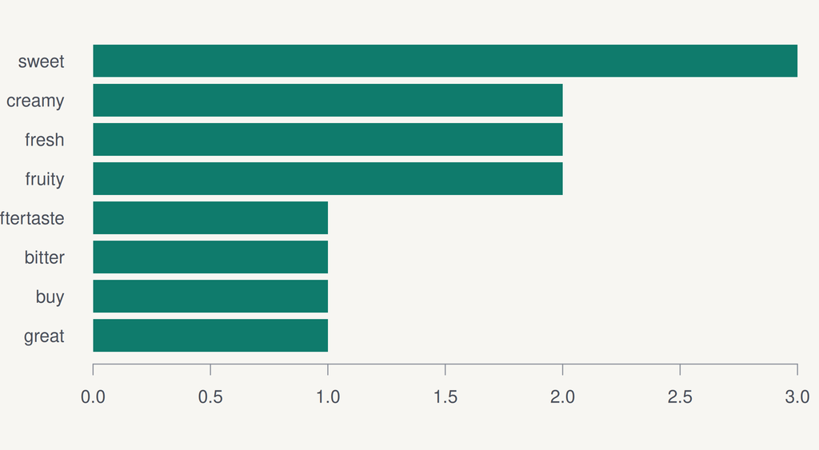

```r
reviews <- c("creamy and sweet, fresh fruity taste",
  "too sour, thin texture, high price",
  "creamy smooth sweet, great product",
  "bitter aftertaste, will not buy again",
  "fresh fruity, pleasant surprise, sweet")
words <- unlist(strsplit(gsub("[[:punct:]]", "",
                              reviews), " +"))
stop <- c("and", "not", "will", "too", "again")
freq <- sort(table(words[!words %in% stop]),
             decreasing = TRUE)[1:8]
barplot(rev(freq), horiz = TRUE, las = 1,
        col = pal[1], border = NA)
```

Before counting, the text must be **cleaned**: lower case, no punctuation or stop words. The `tm` package offers `tm_map()` for that.

## Sentiment analysis – the NRC lexicon

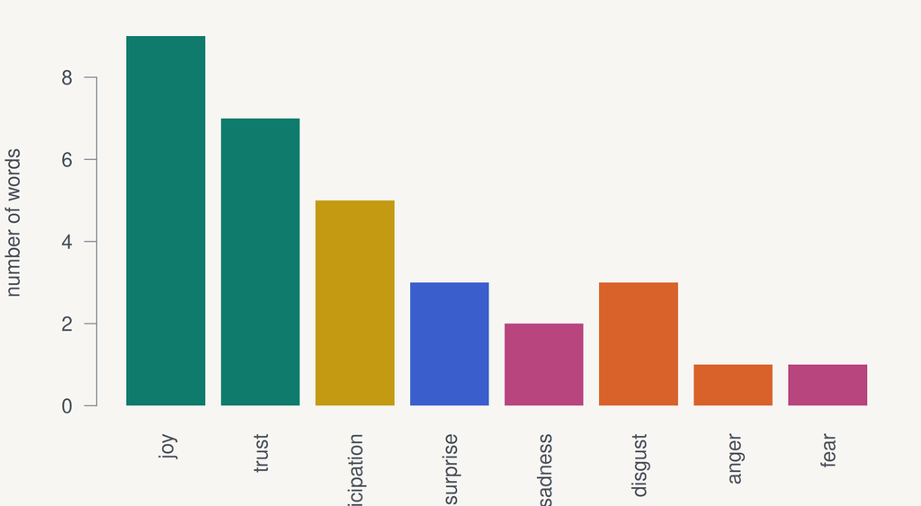

`get_nrc_sentiment()` assigns words the 8 emotions of Plutchik’s wheel and a polarity. Illustrative values; the lexicon does not see context (“not sweet at all”).

## JAR scale

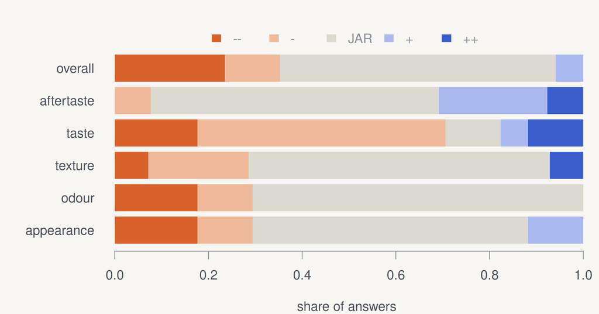

```r
jar <- matrix(c(3, 2, 10, 2, 0, 3, 2, 12, 0, 0, 1, 3, 9, 0, 1, 3, 9, 2, 1, 2, 0, 1, 8, 3, 1, 4, 2, 10, 1, 0),
  ncol = 5, byrow = TRUE, dimnames = list(c("appearance", "odour", "texture", "taste", "aftertaste", "overall"),
                                          c("--", "-", "JAR", "+", "++")))
share <- prop.table(jar, 1)
par(mar = c(4, 7, 3, 1))
barplot(t(share), horiz = TRUE, las = 1, col = c(pal[2], "#f0b99a", "#dcd9d0", "#a9b8ee", pal[3]),
        border = NA, xlab = "share of answers")
legend("top", legend = colnames(jar), fill = c(pal[2], "#f0b99a", "#dcd9d0", "#a9b8ee", pal[3]),
       horiz = TRUE, bty = "n", inset = -0.12, xpd = TRUE, border = NA)
```

Taste has only 12% “just about right” answers and most find it too weak → strengthening the taste is the priority.

## QUIZ What to change?

For sweetness: 60% JAR, 30% “too sweet” and 10% “not sweet enough”. What do you suggest?

Slightly **reduce sweetness** – JAR is above half, but there is a clear asymmetry towards “too much”. Before changing, check with a **penalty analysis** whether this group also rates the product lower.

## Radar chart (profile chart)

```r
library(fmsb)
profile <- data.frame(
  Appearance = c(9, 0, 5.2, 7), Texture = c(9, 0, 4.5, 4.8),
  Odour = c(9, 0, 3.8, 5.8), Taste = c(9, 0, 8, 8),
  Aftertaste = c(9, 0, 8, 8))
par(mar = c(1, 1, 1, 1))
radarchart(profile, pcol = pal[2:3], plwd = 3,
           plty = 1, cglcol = "grey70", vlcex = 1.1)
legend("topright", c("A", "C"), col = pal[2:3],
       lwd = 3, bty = "n")
```

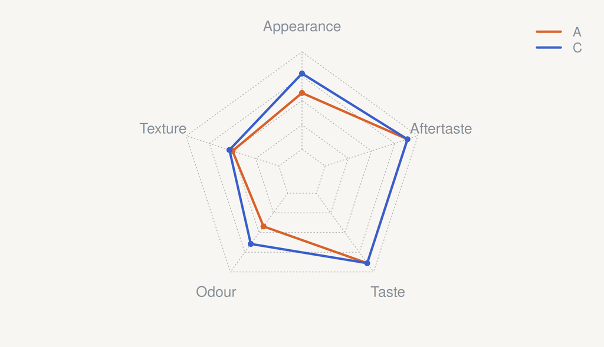

The first two data rows are the axis maximum and minimum. Watch out – the polygon area depends on the order of the axes.

## Summary

| question | method |
| --- | --- |
| how long is the product accepted? | Kaplan-Meier, censored data |
| which combination reaches most people? | TURF (reach, frequency) |
| why are products liked? | preference map |
| what do reviews say? | text mining, sentiment |
| what to change in the recipe? | JAR + penalty analysis |

Theory 10 Theory 11a Theory 11b Theory 12